# Proyecto ¡Mira que Boca! 2024

Test Diferencia de Proporciones

Miguel Franco

2025-01-27

# 1 Introducción

En este documento encontrarán las tablas correspondientes a los test de diferencias entre las proporciones que respaldan las afirmaciones incluidas en la sección “5. Análisis de Resultados”

Los test se han realizado desde una perspectiva frecuentista, con un nivel de significación de $\alpha=0.05$, o lo que es lo mismo, un nivel de confianza del $1-\alpha=0.95$. Los test se realizan como two.sided para reconocer como “estadísticamente diferentes” diferencias tanto “estadísticamente superiores” como “estadísticamente inferiores” (la hipótesis alternativa es la desigualdad en las proporciones).

# 2 RESULT I. Tipo I. Impacto inmediato debido a la intervención (Pre vs. Post)

## 2.1 Diferencias Pre-Post

En este test se somete a prueba la hipótesis nula de que sean iguales las proporciones de alumnos que responden afirmativamente a la pregunta “¿Crees que los piercings pueden dañar los dientes y el resto de tu boca?” antes y después de la intervención.

Es decir, este test evalúa si podemos detectar una diferencia (mejora) estadísticamente significativa en las respuestas después de la intervención.

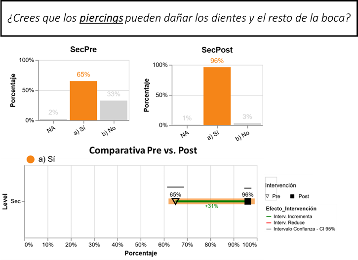

**Result I**

```
##
##  --------------------------------------
##  Filtrado por:  NULL
##  --------------------------------------
##
##  Prop 1
##  --------------------------------------
##  Question 1: P.19.  ¿Crees que los piercings pueden dañar los dientes y el resto de la boca?
##  Response 1: a) Sí
##  Dataset 1: SecPre
##  filtro 1: NULL
##
##  Prop2
##  --------------------------------------
##  Question 2: P.9.  ¿Crees que los piercings pueden dañar los dientes y el resto de la boca?
##  Response 2: a) Sí
##  Dataset 2: SecPost
##  Filtro 2: NULL
##
##  --------------------------------------
```

```
##
##  2-sample test for equality of proportions with continuity correction
##
## data:  c(P1$x, P2$x) out of c(P1$n, P2$n)
## X-squared = 192.3, df = 1, p-value < 2.2e-16
## alternative hypothesis: two.sided
## 95 percent confidence interval:
##  -0.3516134 -0.2702469
## sample estimates:
##    prop 1    prop 2
## 0.6502976 0.9612278
```

Existen diferencias estadísticamente significativas entre los valores de respuestas posteriores y previas a la intervención. Ha habido una mejora significativa en los conocimientos sobre el efecto de los piercings orales después de la intervención.

## 2.2 Conclusión

Queda sustentada estadísticamente la siguiente afirmación:

- Hay una mejora significativa tras la intervención en Secundaria (esta pregunta e información NO se incluía en Primaria)

# 3 RESULT II. Tipo II. Efecto Nivel Educativo (Primaria vs. Secundaria)

En esta sección se somete a prueba si las proporciones de alumnos que responden “Cepillo dental” a la pregunta “¿Cuál consideras imprescindible para la higiene de los dientes?” son idénticas en Primaria y Secundaria. Para ello comprobaremos si dichas proporciones son razonablemente iguales antes de la intervención y luego comprobaremos si son razonablemente iguales después de la intervención.

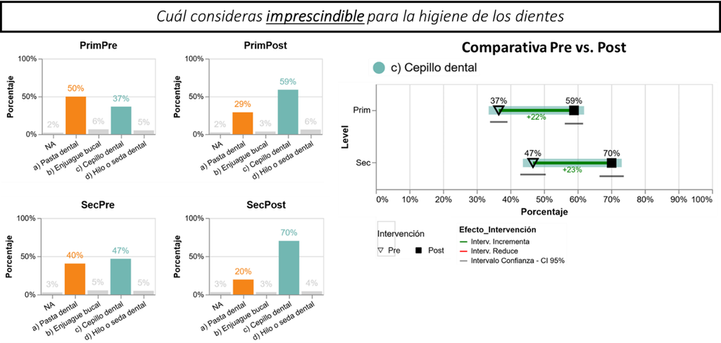

**Result II**

## 3.1 Diferencias Primaria-Secundaria (PRE - antes de la intervención)

Este test evalúa si podemos detectar una diferencia estadísticamente significativa en las respuestas antes de la intervención al comparar los dos niveles educativos (Primaria vs. Secundaria).

```
##
##  --------------------------------------
##  Filtrado por:  NULL
##  --------------------------------------
##
##  Prop 1
##  --------------------------------------
##  Question 1: P.7. De las cuatro alternativas, señala la que consideres imprescindible (sólo una) para la higiene de los dientes
##  Response 1: c) Cepillo dental
##  Dataset 1: PrimPre
##  filtro 1: NULL
##
##  Prop2
##  --------------------------------------
##  Question 2: P.8. De las cuatro alternativas, señala la que consideres imprescindible (sólo una) para la higiene de los dientes
##  Response 2: c) Cepillo dental
##  Dataset 2: SecPre
##  Filtro 2: NULL
##
##  --------------------------------------
```

```
##
##  2-sample test for equality of proportions with continuity correction
##
## data:  c(P1$x, P2$x) out of c(P1$n, P2$n)
## X-squared = 18.836, df = 1, p-value = 1.424e-05
## alternative hypothesis: two.sided
## 95 percent confidence interval:
##  -0.14866042 -0.05489128
## sample estimates:
##    prop 1    prop 2
## 0.3654861 0.4672619
```

Con un p-valor de $1.424~*~10^{-5}$ y un intervalo de confianza al 95% para la diferencia Secundaria-Primaria de $[0.055,0.149]$ se rechaza la hipótesis nula de que ambas proporciones puedan ser iguales (diferencia Secundaria-Primaria nula) bajo el nivel muestral aportado.

Existen diferencias estadísticamente significativas entre los valores de respuestas de secundaria y primaria previas a la intervención. Los estudiantes de secundaria muestran un patrón de respuestas previas estadísticamente superior al de los estudiantes de primaria.

## 3.2 Diferencias Primaria-Secundaria (POST - después de la intervención)

Este test evalúa si podemos detectar una diferencia estadísticamente significativa en las respuestas después de la intervención al comparar los dos niveles educativos (Primaria vs. Secundaria).

```
##
##  --------------------------------------
##  Filtrado por:  NULL
##  --------------------------------------
##
##  Prop 1
##  --------------------------------------
##  Question 1: P.4. De las cuatro alternativas, señala la que consideres imprescindible (sólo una) para la higiene de los dientes
##  Response 1: c) Cepillo dental
##  Dataset 1: PrimPost
##  filtro 1: NULL
##
##  Prop2
##  --------------------------------------
##  Question 2: P.4. De las cuatro alternativas, señala la que consideres imprescindible (sólo una) para la higiene de los dientes
##  Response 2: c) Cepillo dental
##  Dataset 2: SecPost
##  Filtro 2: NULL
##
##  --------------------------------------
```

```
##
##  2-sample test for equality of proportions with continuity correction
##
## data:  c(P1$x, P2$x) out of c(P1$n, P2$n)
## X-squared = 21.802, df = 1, p-value = 3.023e-06
## alternative hypothesis: two.sided
## 95 percent confidence interval:
##  -0.15839043 -0.06572402
## sample estimates:
##    prop 1    prop 2
## 0.5890736 0.7011309
```

Con un p-valor de $3.023~*~10^{-6}$ y un intervalo de confianza al 95% para la diferencia Secundaria-Primaria de $[0.066,0.158]$ se rechaza la hipótesis nula de que ambas proporciones puedan ser iguales (diferencia Secundaria-Primaria nula) bajo el nivel muestral aportado.

Existen diferencias estadísticamente significativas entre los valores de respuestas de secundaria y primaria posteriores a la intervención. Los estudiantes de secundaria muestran un patrón de respuestas posteriores estadísticamente superior al de los estudiantes de primaria.

## 3.3 Diferencias Pre-Post (Primaria)

Este test evalúa si podemos detectar una diferencia (mejora) estadísticamente significativa en las respuestas después de la intervención en los estudiantes de Primaria.

```
##
##  --------------------------------------
##  Filtrado por:  NULL
##  --------------------------------------
##
##  Prop 1
##  --------------------------------------
##  Question 1: P.7. De las cuatro alternativas, señala la que consideres imprescindible (sólo una) para la higiene de los dientes
##  Response 1: c) Cepillo dental
##  Dataset 1: PrimPre
##  filtro 1: NULL
##
##  Prop2
##  --------------------------------------
##  Question 2: P.4. De las cuatro alternativas, señala la que consideres imprescindible (sólo una) para la higiene de los dientes
##  Response 2: c) Cepillo dental
##  Dataset 2: PrimPost
##  Filtro 2: NULL
##
##  --------------------------------------
```

```
##
##  2-sample test for equality of proportions with continuity correction
##
## data:  c(P1$x, P2$x) out of c(P1$n, P2$n)
## X-squared = 128.84, df = 1, p-value < 2.2e-16
## alternative hypothesis: two.sided
## 95 percent confidence interval:
##  -0.2618780 -0.1852971
## sample estimates:
##    prop 1    prop 2
## 0.3654861 0.5890736
```

Con un p-valor inferior a $2.2~*~10^{-16}$ y un intervalo de confianza al 95% para la diferencia Pre-Post de $[0.185,0.262]$ se rechaza la hipótesis nula de que ambas proporciones puedan ser iguales en Primaria (diferencia Post-Pre nula) bajo el nivel muestral aportado.

Existen diferencias estadísticamente significativas entre los valores de respuestas posteriores y previas a la intervención. Ha habido una mejora significativa en los conocimientos sobre la primacía del cepillo dental en la higiene bucal en Primaria.

## 3.4 Diferencias Pre-Post (Secundaria)

Este test evalúa si podemos detectar una diferencia (mejora) estadísticamente significativa en las respuestas después de la intervención en los estudiantes de Secundaria

```
##
##  --------------------------------------
##  Filtrado por:  NULL
##  --------------------------------------
##
##  Prop 1
##  --------------------------------------
##  Question 1: P.8. De las cuatro alternativas, señala la que consideres imprescindible (sólo una) para la higiene de los dientes
##  Response 1: c) Cepillo dental
##  Dataset 1: SecPre
##  filtro 1: NULL
##
##  Prop2
##  --------------------------------------
##  Question 2: P.4. De las cuatro alternativas, señala la que consideres imprescindible (sólo una) para la higiene de los dientes
##  Response 2: c) Cepillo dental
##  Dataset 2: SecPost
##  Filtro 2: NULL
##
##  --------------------------------------
```

```
##
##  2-sample test for equality of proportions with continuity correction
##
## data:  c(P1$x, P2$x) out of c(P1$n, P2$n)
## X-squared = 71.359, df = 1, p-value < 2.2e-16
## alternative hypothesis: two.sided
## 95 percent confidence interval:
##  -0.2876071 -0.1801308
## sample estimates:
##    prop 1    prop 2
## 0.4672619 0.7011309
```

Con un p-valor inferior a $2.2~*~10^{-16}$ y un intervalo de confianza al 95% para la diferencia Pre-Post de $[0.180,0.288]$ se rechaza la hipótesis nula de que ambas proporciones puedan ser iguales en Secundaria (diferencia Post-Pre nula) bajo el nivel muestral aportado.

Existen diferencias estadísticamente significativas entre los valores de respuestas posteriores y previas a la intervención. Ha habido una mejora significativa en los conocimientos sobre la primacía del cepillo dental en la higiene bucal en Secundaria

## 3.5 Conclusión

Quedan sustentadas estadísticamente las siguientes afirmaciones:

- El nivel inicial (PRE) de los estudiantes de Secundaria es superior al de Primaria
- El nivel final (POST) de los estudiantes de Secundaria es superior al de Primaria
- Hay una mejora significativa tras la intervención en Primaria
- Hay una mejora significativa tras la intervención en Secundaria

# 4 RESULT III. Tipo III. Incongruencia Hábito vs. Conocimiento

En esta sección se somete a prueba si la proporción de estudiantes que SABEN (conocimiento) que deben acudir cada 6 meses a la consulta de higiene bucodental se corresponden con la proporción de estudiantes que ACUDEN (hábito) con dicha regularidad.

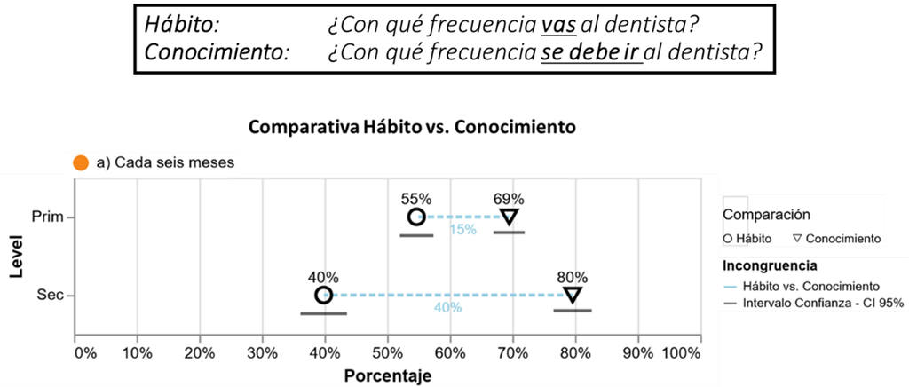

## Diferencias Hábito-Conocimiento (Primaria)

Este test evalúa si podemos detectar una diferencia estadísticamente significativa entre el conocimiento de periodicidad adecuada de visitas al gabinete de salud oral y el hábito (si realmente se cumple) entre los alumnos de Primaria.

```
##
##  --------------------------------------
##  Filtrado por:  NULL
##  --------------------------------------
##
##  Prop 1
##  --------------------------------------
##  Question 1: P.1. ¿Con qué frecuencia vas al dentista?
##  Response 1: a) Cada seis meses
##  Dataset 1: PrimPre
##  filtro 1: NULL
##
##  Prop2
##  --------------------------------------
##  Question 2: P.2. ¿Con que frecuencia crees que se debe ir al dentista?
##  Response 2: a) Cada seis meses
##  Dataset 2: PrimPre
##  Filtro 2: NULL
##
##  --------------------------------------
```

```
##
##  2-sample test for equality of proportions with continuity correction
##
## data:  c(P1$x, P2$x) out of c(P1$n, P2$n)
## X-squared = 60.872, df = 1, p-value = 6.092e-15
## alternative hypothesis: two.sided
## 95 percent confidence interval:
##  -0.1849401 -0.1104631
## sample estimates:
##    prop 1    prop 2
## 0.5470987 0.6948003
```

Con un p-valor de $6.092~*~10^{-15}$ y un intervalo de confianza al 95% para la diferencia hábito-conocimiento de $[0.11,0.18]$ se rechaza la hipótesis nula de que ambas proporciones (hábito y conocimiento) puedan ser iguales en Primaria (diferencia hábito-conocimiento nula) bajo el nivel muestral aportado.

Existen diferencias estadísticamente significativas entre los valores de respuestas de hábito y conocimiento. Existe una incongruencia en el hábito que lleva a NO cumplir con la revisión oral semestral que SE SABE que es la adecuada entre los alumnos de Primaria.

## 4.1 Diferencias Hábito-Conocimiento (Secundaria)

Este test evalúa si podemos detectar una diferencia estadísticamente significativa entre el conocimiento de periodicidad adecuada de visitas al gabinete de salud oral y el hábito (si realmente se cumple) entre los alumnos de Secundaria.

```
##
##  --------------------------------------
##  Filtrado por:  NULL
##  --------------------------------------
##
##  Prop 1
##  --------------------------------------
##  Question 1: P.1. ¿Con qué frecuencia vas al dentista?
##  Response 1: a) Cada seis meses
##  Dataset 1: SecPre
##  filtro 1: NULL
##
##  Prop2
##  --------------------------------------
##  Question 2: P.2. ¿Con que frecuencia crees que se debe ir al dentista?
##  Response 2: a) Cada seis meses
##  Dataset 2: SecPre
##  Filtro 2: NULL
##
##  --------------------------------------
```

```
##
##  2-sample test for equality of proportions with continuity correction
##
## data:  c(P1$x, P2$x) out of c(P1$n, P2$n)
## X-squared = 218.9, df = 1, p-value < 2.2e-16
## alternative hypothesis: two.sided
## 95 percent confidence interval:
##  -0.4467511 -0.3478917
## sample estimates:
##    prop 1    prop 2
## 0.3988095 0.7961310
```

Con un p-valor inferior a $2.2~*~10^{-16}$ y un intervalo de confianza al 95% para la diferencia hábito-conocimiento de $[0.348,0.447]$ se rechaza la hipótesis nula de que ambas proporciones (hábito y conocimiento) puedan ser iguales en Secundaria (diferencia hábito-conocimiento nula) bajo el nivel muestral aportado.

Existen diferencias estadísticamente significativas entre los valores de respuestas de hábito y conocimiento. Existe una incongruencia en el hábito que lleva a NO cumplir con la revisión oral semestral que SE SABE que es la adecuada entre los alumnos de Secundaria.

## 4.2 Diferencias Primaria-Secundaria (Conocimiento)

Este test evalúa si podemos detectar una diferencia estadísticamente significativa en los conocimientos de periodicidad adecuada en la visita al gabinete de salud oral al comparar los dos niveles educativos (Primaria vs. Secundaria).

```
##
##  --------------------------------------
##  Filtrado por:  NULL
##  --------------------------------------
##
##  Prop 1
##  --------------------------------------
##  Question 1: P.2. ¿Con que frecuencia crees que se debe ir al dentista?
##  Response 1: a) Cada seis meses
##  Dataset 1: PrimPre
##  filtro 1: NULL
##
##  Prop2
##  --------------------------------------
##  Question 2: P.2. ¿Con que frecuencia crees que se debe ir al dentista?
##  Response 2: a) Cada seis meses
##  Dataset 2: SecPre
##  Filtro 2: NULL
##
##  --------------------------------------
```

```
##
##  2-sample test for equality of proportions with continuity correction
##
## data:  c(P1$x, P2$x) out of c(P1$n, P2$n)
## X-squared = 22.668, df = 1, p-value = 1.925e-06
## alternative hypothesis: two.sided
## 95 percent confidence interval:
##  -0.14171569 -0.06094561
## sample estimates:
##    prop 1    prop 2
## 0.6948003 0.7961310
```

Con un p-valor de $1.925~*~10^{-6}$ y un intervalo de confianza al 95% para la diferencia Secundaria-Primaria de $[0.06,0.14]$ se rechaza la hipótesis nula de que ambas proporciones puedan ser iguales (diferencia Secundaria-Primaria nula) bajo el nivel muestral aportado.

Existen diferencias estadísticamente significativas entre los conocimientos de secundaria y primaria . Los estudiantes de secundaria muestran un patrón de conocimientos estadísticamente superior al de los estudiantes de primaria.

## 4.3 Diferencias Primaria-Secundaria (Hábito)

Este test evalúa si podemos detectar una diferencia estadísticamente significativa en los hábitos de periodicidad en la visita al gabinete de salud oral al comparar los dos niveles educativos (Primaria vs. Secundaria).

```
##
##  --------------------------------------
##  Filtrado por:  NULL
##  --------------------------------------
##
##  Prop 1
##  --------------------------------------
##  Question 1: P.1. ¿Con qué frecuencia vas al dentista?
##  Response 1: a) Cada seis meses
##  Dataset 1: PrimPre
##  filtro 1: NULL
##
##  Prop2
##  --------------------------------------
##  Question 2: P.1. ¿Con qué frecuencia vas al dentista?
##  Response 2: a) Cada seis meses
##  Dataset 2: SecPre
##  Filtro 2: NULL
##
##  --------------------------------------
```

```
##
##  2-sample test for equality of proportions with continuity correction
##
## data:  c(P1$x, P2$x) out of c(P1$n, P2$n)
## X-squared = 38.648, df = 1, p-value = 5.075e-10
## alternative hypothesis: two.sided
## 95 percent confidence interval:
##  0.1014751 0.1951032
## sample estimates:
##    prop 1    prop 2
## 0.5470987 0.3988095
```

Con un p-valor de $5.075~*~10^{-10}$ y un intervalo de confianza al 95% para la diferencia Secundaria-Primaria de $[0.10,0.20]$ se rechaza la hipótesis nula de que ambas proporciones puedan ser iguales (diferencia Secundaria-Primaria nula) bajo el nivel muestral aportado.

## 4.4 Conclusión

Quedan sustentadas estadísticamente las siguientes afirmaciones:

- El conocimiento de periodicidad adecuada en la visita al gabinete de salud oral es mayor que el hábito con que se cumple dicha periodicidad en Primaria.
- El conocimiento de periodicidad adecuada en la visita al gabinete de salud oral es mayor que el hábito con que se cumple dicha periodicidad en Secundaria.
- El conocimiento de periodicidad adecuada en la visita al gabinete de salud oral es mayor en los estudiantes de Secundaria.
- El hábito de periodicidad adecuada en la visita al gabinete de salud oral es mayor en los estudiantes de Primaria que en sus mayores de Secundaria.

# 5 RESULT IV. Tipo IV. Efecto Sexo (Hombre vs. Mujer)

En esta sección se somete a prueba si la proporción de estudiantes HOMBRES que consumen bebidas energéticas es razonablemente semejante a la de las estudiantes MUJERES teniendo en cuenta la edad (nivel educativo). Posteriormente, sometemos a prueba estadística si el consumo aumenta de primaria a secundaria teniendo en cuenta el sexo.

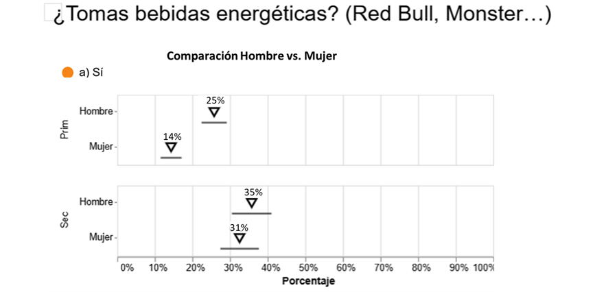

**Result IV**

## 5.1 Diferencias Hombre-Mujer (PRIMARIA)

Este test evalúa si podemos detectar una diferencia estadísticamente significativa en los hábitos de consumo de bebidas energéticas entre los hombres y las mujeres de Primaria.

```
##
##  --------------------------------------
##  Filtrado por:  Sexo
##  --------------------------------------
##
##  Prop 1
##  --------------------------------------
##  Question 1: P.14. ¿Tomas bebidas energéticas? (Red Bull, Monster…)
##  Response 1: R) Sí
##  Dataset 1: PrimPre
##  filtro 1: Home
##
##  Prop2
##  --------------------------------------
##  Question 2: P.14. ¿Tomas bebidas energéticas? (Red Bull, Monster…)
##  Response 2: R) Sí
##  Dataset 2: PrimPre
##  Filtro 2: Muller
##
##  --------------------------------------
```

```
##
##  2-sample test for equality of proportions with continuity correction
##
## data:  c(P1$x, P2$x) out of c(P1$n, P2$n)
## X-squared = 24.904, df = 1, p-value = 6.024e-07
## alternative hypothesis: two.sided
## 95 percent confidence interval:
##  0.06924702 0.15921969
## sample estimates:
##    prop 1    prop 2
## 0.2549618 0.1407285
```

Con un p-valor de $6.024~*~10^{-7}$ y un intervalo de confianza al 95% para la diferencia Hombre-Mujer de $[0.069,0.159]$ se rechaza la hipótesis nula de que ambas proporciones puedan ser iguales (diferencia Hombre-Mujer nula) bajo el nivel muestral aportado.

Existen diferencias estadísticamente significativas en los hábitos de consumo de bebidas energéticas entre hombres y mujeres de Primaria. Los hombres de primaria consumen más que las chicas de primaria.

## 5.2 Diferencias Hombre-Mujer (SECUNDARIA)

Este test evalúa si podemos detectar una diferencia estadísticamente significativa en los hábitos de consumo de bebidas energéticas entre los hombres y las mujeres de Secundaria.

```
##
##  --------------------------------------
##  Filtrado por:  Sexo
##  --------------------------------------
##
##  Prop 1
##  --------------------------------------
##  Question 1: P.14.  ¿Tomas bebidas energéticas?
##  Response 1: R) Sí
##  Dataset 1: SecPre
##  filtro 1: Home
##
##  Prop2
##  --------------------------------------
##  Question 2: P.14.  ¿Tomas bebidas energéticas?
##  Response 2: R) Sí
##  Dataset 2: SecPre
##  Filtro 2: Muller
##
##  --------------------------------------
```

```
##
##  2-sample test for equality of proportions with continuity correction
##
## data:  c(P1$x, P2$x) out of c(P1$n, P2$n)
## X-squared = 0.6042, df = 1, p-value = 0.437
## alternative hypothesis: two.sided
## 95 percent confidence interval:
##  -0.04401545  0.10812714
## sample estimates:
##    prop 1    prop 2
## 0.3540373 0.3219814
```

NO existen diferencias estadísticamente significativas en los hábitos de consumo de bebidas energéticas entre hombres y mujeres de Secundaria. En secundaria, hombres y mujeres consumen bebidas energéticas en aproximadamente la misma proporción.

## 5.3 Diferencias Edad (Hombres)

Este test evalúa si podemos detectar una variación (aumento) estadísticamente significativa en los hábitos de consumo de bebidas energéticas entre los hombres al pasar de Primaria a Secundaria.

```
##
##  --------------------------------------
##  Filtrado por:  Sexo
##  --------------------------------------
##
##  Prop 1
##  --------------------------------------
##  Question 1: P.14. ¿Tomas bebidas energéticas? (Red Bull, Monster…)
##  Response 1: R) Sí
##  Dataset 1: PrimPre
##  filtro 1: Home
##
##  Prop2
##  --------------------------------------
##  Question 2: P.14.  ¿Tomas bebidas energéticas?
##  Response 2: R) Sí
##  Dataset 2: SecPre
##  Filtro 2: Home
##
##  --------------------------------------
```

```
##
##  2-sample test for equality of proportions with continuity correction
##
## data:  c(P1$x, P2$x) out of c(P1$n, P2$n)
## X-squared = 9.8642, df = 1, p-value = 0.001685
## alternative hypothesis: two.sided
## 95 percent confidence interval:
##  -0.16337860 -0.03477227
## sample estimates:
##    prop 1    prop 2
## 0.2549618 0.3540373
```

Con un p-valor de $1.69~*~10^{-3}$ y un intervalo de confianza al 95% para la diferencia Primaria-Secundaria de $[0.035,0.163]$ se rechaza la hipótesis nula de que ambas proporciones puedan ser iguales (diferencia Primaria-Secundaria nula) bajo el nivel muestral aportado.

Existen diferencias estadísticamente significativas en los hábitos de consumo de bebidas energéticas en hombres al pasar de Primaria a Secundaria. En secundaria, mayor proporción de hombres consumen bebidas energéticas.

## 5.4 Diferencias Edad (Mujeres)

Este test evalúa si podemos detectar una variación (aumento) estadísticamente significativa en los hábitos de consumo de bebidas energéticas entre las mujeres al pasar de Primaria a Secundaria.

```
##
##  --------------------------------------
##  Filtrado por:  Sexo
##  --------------------------------------
##
##  Prop 1
##  --------------------------------------
##  Question 1: P.14. ¿Tomas bebidas energéticas? (Red Bull, Monster…)
##  Response 1: R) Sí
##  Dataset 1: PrimPre
##  filtro 1: Muller
##
##  Prop2
##  --------------------------------------
##  Question 2: P.14.  ¿Tomas bebidas energéticas?
##  Response 2: R) Sí
##  Dataset 2: SecPre
##  Filtro 2: Muller
##
##  --------------------------------------
```

```
##
##  2-sample test for equality of proportions with continuity correction
##
## data:  c(P1$x, P2$x) out of c(P1$n, P2$n)
## X-squared = 41.487, df = 1, p-value = 1.187e-10
## alternative hypothesis: two.sided
## 95 percent confidence interval:
##  -0.2416412 -0.1208647
## sample estimates:
##    prop 1    prop 2
## 0.1407285 0.3219814
```

Con un p-valor de $1.187~*~10^{-10}$ y un intervalo de confianza al 95% para la diferencia Primaria-Secundaria de $[0.12,0.24]$ se rechaza la hipótesis nula de que ambas proporciones puedan ser iguales (diferencia Primaria-Secundaria nula) bajo el nivel muestral aportado.

Existen diferencias estadísticamente significativas en los hábitos de consumo de bebidas energéticas en mujeres al pasar de Primaria a Secundaria. En secundaria, mayor proporción de mujeres consumen bebidas energéticas.

## 5.5 Conclusión

Quedan sustentadas estadísticamente las siguientes afirmaciones:

- En Primaria, los hombres consumen bebidas energéticas en mayor proporción que las mujeres.
- En Secundaria, los hombres y mujeres consumen bebidas energéticas en una proporción semejante.
- El consumo de bebidas energéticas aumenta de Primaria a Secundaria para los hombres.
- El consumo de bebidas energéticas aumenta de Primaria a Secundaria para las mujeres.